# NY Mets Analysis and Visualizations

Kirsten Hugh

Feb 2024

```python
import os
import pandas as pd
from matplotlib import pyplot as plt
%matplotlib inline
import seaborn as sns
import matplotlib.ticker as ticker #to reduce ticks
```

```python
#import 2022 file
df_22 = pd.read_csv("mets_2022.csv")
df_22.head()
```

|  | Gm# | Date | Unnamed: 2 | Tm | Unnamed: 4 | Opp | W/L | R | RA | Inn | ... | GB | Win | Loss | Save | Time | D/N | Attendance | cLI | Streak | Orig. Scheduled |
| --- | --- | --- | --- | --- | --- | --- | --- | --- | --- | --- | --- | --- | --- | --- | --- | --- | --- | --- | --- | --- | --- |
| 0 | 1 | Thursday Apr 7 | boxscore | NYM | @ | WSN | W | 5 | 1 | NaN | ... | up 0.5 | Megill | Corbin | NaN | 3:31 | N | 35052.0 | 1.02 | + | NaN |
| 1 | 2 | Friday Apr 8 | boxscore | NYM | @ | WSN | W | 7 | 3 | NaN | ... | up 0.5 | Scherzer | Gray | NaN | 3:43 | N | 25677.0 | 1.01 | ++ | NaN |
| 2 | 3 | Saturday Apr 9 | boxscore | NYM | @ | WSN | W | 5 | 0 | NaN | ... | up 0.5 | Bassitt | Adon | NaN | 3:14 | N | 21369.0 | 1.12 | +++ | NaN |
| 3 | 4 | Sunday Apr 10 | boxscore | NYM | @ | WSN | L | 2 | 4 | NaN | ... | up 0.5 | Finnegan | Williams | Rainey | 3:01 | D | 23158.0 | 1.06 | - | NaN |
| 4 | 5 | Monday Apr 11 | boxscore | NYM | @ | PHI | L | 4 | 5 | NaN | ... | 0.5 | Domínguez | Lugo | Hand | 3:05 | N | 22317.0 | 1.13 | -- | NaN |

5 rows × 22 columns

```python
#Name unnamed columns, rename Gm#
df_22 = df_22.rename(columns = {'Unnamed: 2': 'Boxscore',
                        'Unnamed: 4': 'Away',
                        'Gm#' : "Game"})
df_22.head()
```

|  | Game | Date | Boxscore | Tm | Away | Opp | W/L | R | RA | Inn | ... | GB | Win | Loss | Save | Time | D/N | Attendance | cLI | Streak | Orig. Scheduled |
| --- | --- | --- | --- | --- | --- | --- | --- | --- | --- | --- | --- | --- | --- | --- | --- | --- | --- | --- | --- | --- | --- |
| 0 | 1 | Thursday Apr 7 | boxscore | NYM | @ | WSN | W | 5 | 1 | NaN | ... | up 0.5 | Megill | Corbin | NaN | 3:31 | N | 35052.0 | 1.02 | + | NaN |
| 1 | 2 | Friday Apr 8 | boxscore | NYM | @ | WSN | W | 7 | 3 | NaN | ... | up 0.5 | Scherzer | Gray | NaN | 3:43 | N | 25677.0 | 1.01 | ++ | NaN |
| 2 | 3 | Saturday Apr 9 | boxscore | NYM | @ | WSN | W | 5 | 0 | NaN | ... | up 0.5 | Bassitt | Adon | NaN | 3:14 | N | 21369.0 | 1.12 | +++ | NaN |
| 3 | 4 | Sunday Apr 10 | boxscore | NYM | @ | WSN | L | 2 | 4 | NaN | ... | up 0.5 | Finnegan | Williams | Rainey | 3:01 | D | 23158.0 | 1.06 | - | NaN |
| 4 | 5 | Monday Apr 11 | boxscore | NYM | @ | PHI | L | 4 | 5 | NaN | ... | 0.5 | Domínguez | Lugo | Hand | 3:05 | N | 22317.0 | 1.13 | -- | NaN |

5 rows × 22 columns

```python
df_22.describe()
```

|  | Game | R | RA | Inn | Rank | Attendance | cLI | Orig. Scheduled |
| --- | --- | --- | --- | --- | --- | --- | --- | --- |
| count | 162.000000 | 162.000000 | 162.000000 | 12.000000 | 162.000000 | 157.000000 | 162.000000 | 0.0 |
| mean | 81.500000 | 4.765432 | 3.740741 | 10.083333 | 1.037037 | 31281.140127 | 1.105000 | NaN |
| std | 46.909487 | 3.125816 | 2.868885 | 0.288675 | 0.189438 | 9114.145312 | 0.400322 | NaN |
| min | 1.000000 | 0.000000 | 0.000000 | 10.000000 | 1.000000 | 8717.000000 | 0.030000 | NaN |
| 25% | 41.250000 | 2.000000 | 2.000000 | 10.000000 | 1.000000 | 25417.000000 | 0.962500 | NaN |
| 50% | 81.500000 | 4.500000 | 3.000000 | 10.000000 | 1.000000 | 32215.000000 | 1.100000 | NaN |
| 75% | 121.750000 | 7.000000 | 5.000000 | 10.000000 | 1.000000 | 37452.000000 | 1.207500 | NaN |
| max | 162.000000 | 13.000000 | 13.000000 | 11.000000 | 2.000000 | 52505.000000 | 4.110000 | NaN |

```python
#import 2023 file
df_23 = pd.read_csv("mets_2023.csv")
df_23.head()
```

|  | Gm# | Date | Unnamed: 2 | Tm | Unnamed: 4 | Opp | W/L | R | RA | Inn | ... | GB | Win | Loss | Save | Time | D/N | Attendance | cLI | Streak | Orig. Scheduled |
| --- | --- | --- | --- | --- | --- | --- | --- | --- | --- | --- | --- | --- | --- | --- | --- | --- | --- | --- | --- | --- | --- |
| 0 | 1 | Thursday Mar 30 | boxscore | NYM | @ | MIA | W | 5 | 3 | NaN | ... | Tied | Scherzer | Scott | Robertson | 2:42 | D | 31397.0 | 0.97 | + | NaN |
| 1 | 2 | Friday Mar 31 | boxscore | NYM | @ | MIA | L | 1 | 2 | NaN | ... | 0.5 | Luzardo | Peterson | Puk | 2:09 | N | 14797.0 | 1.07 | - | NaN |
| 2 | 3 | Saturday Apr 1 | boxscore | NYM | @ | MIA | W | 6 | 2 | NaN | ... | 0.5 | Megill | Nardi | NaN | 2:54 | D | 14695.0 | 1.01 | + | NaN |
| 3 | 4 | Sunday Apr 2 | boxscore | NYM | @ | MIA | W | 5 | 1 | NaN | ... | up 0.5 | Senga | Rogers | NaN | 2:40 | D | 18322.0 | 1.08 | ++ | NaN |
| 4 | 5 | Monday Apr 3 | boxscore | NYM | @ | MIL | L | 0 | 10 | NaN | ... | 0.5 | Peralta | Carrasco | Wilson | 2:37 | D | 42017.0 | 1.09 | - | NaN |

5 rows × 22 columns

```python
#Name unnamed columns
df_23 = df_23.rename(columns = {'Unnamed: 2': 'Boxscore',
                        'Unnamed: 4': 'Away',
                        'Gm#' : 'Game'})
df_23.head()
```

|  | Game | Date | Boxscore | Tm | Away | Opp | W/L | R | RA | Inn | ... | GB | Win | Loss | Save | Time | D/N | Attendance | cLI | Streak | Orig. Scheduled |
| --- | --- | --- | --- | --- | --- | --- | --- | --- | --- | --- | --- | --- | --- | --- | --- | --- | --- | --- | --- | --- | --- |
| 0 | 1 | Thursday Mar 30 | boxscore | NYM | @ | MIA | W | 5 | 3 | NaN | ... | Tied | Scherzer | Scott | Robertson | 2:42 | D | 31397.0 | 0.97 | + | NaN |
| 1 | 2 | Friday Mar 31 | boxscore | NYM | @ | MIA | L | 1 | 2 | NaN | ... | 0.5 | Luzardo | Peterson | Puk | 2:09 | N | 14797.0 | 1.07 | - | NaN |
| 2 | 3 | Saturday Apr 1 | boxscore | NYM | @ | MIA | W | 6 | 2 | NaN | ... | 0.5 | Megill | Nardi | NaN | 2:54 | D | 14695.0 | 1.01 | + | NaN |
| 3 | 4 | Sunday Apr 2 | boxscore | NYM | @ | MIA | W | 5 | 1 | NaN | ... | up 0.5 | Senga | Rogers | NaN | 2:40 | D | 18322.0 | 1.08 | ++ | NaN |
| 4 | 5 | Monday Apr 3 | boxscore | NYM | @ | MIL | L | 0 | 10 | NaN | ... | 0.5 | Peralta | Carrasco | Wilson | 2:37 | D | 42017.0 | 1.09 | - | NaN |

5 rows × 22 columns

```python
df_23.describe()
```

|  | Game | R | RA | Inn | Rank | Attendance | cLI | Orig. Scheduled |
| --- | --- | --- | --- | --- | --- | --- | --- | --- |
| count | 162.000000 | 162.000000 | 162.000000 | 12.000000 | 162.000000 | 159.000000 | 162.000000 | 0.0 |
| mean | 81.500000 | 4.425926 | 4.500000 | 9.416667 | 3.376543 | 31395.371069 | 0.548395 | NaN |
| std | 46.909487 | 3.247179 | 3.224999 | 1.505042 | 0.965333 | 9179.125070 | 0.450590 | NaN |
| min | 1.000000 | 0.000000 | 0.000000 | 5.000000 | 1.000000 | 10897.000000 | 0.000000 | NaN |
| 25% | 41.250000 | 2.000000 | 2.000000 | 10.000000 | 2.000000 | 25619.500000 | 0.105000 | NaN |
| 50% | 81.500000 | 4.000000 | 4.000000 | 10.000000 | 4.000000 | 33185.000000 | 0.385000 | NaN |
| 75% | 121.750000 | 6.750000 | 6.000000 | 10.000000 | 4.000000 | 38134.500000 | 1.017500 | NaN |
| max | 162.000000 | 17.000000 | 21.000000 | 10.000000 | 5.000000 | 50313.000000 | 1.340000 | NaN |

## Analysis of Summary Statistics

The mean cLI in 2022 was 1.105000 and in 2023 it was 0.548395, implying that in 2022 the Mets' games had about average importance on the team's probability of winning the World Series, and in 2023 they had a significantly less than average importance per game on the team's probability of winning the World Series.

# 2022 and 2023 Time Series of NYM Game Attendance

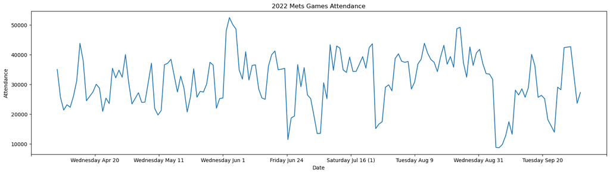

```python
#2022 times series of Met Games Attendance
fig = plt.subplots(figsize=(20, 5)) #set figure size

plot = sns.lineplot(data = df_22, x = df_22.Date, y = df_22.Attendance)

plot.xaxis.set_major_locator(ticker.LinearLocator(10)) #reduces density of xticks

plt.title('2022 Mets Games Attendance')
plt.xlabel('Date')
plt.ylabel('Attendance')
```

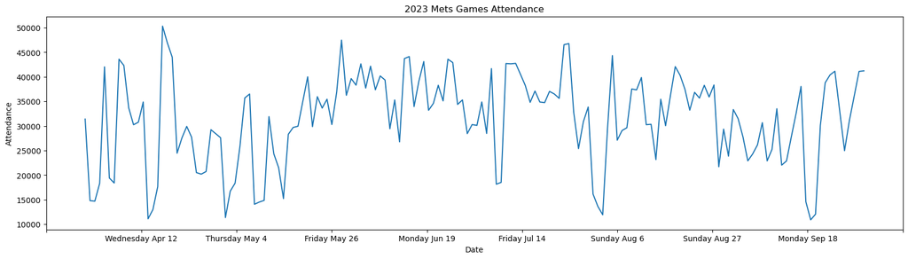

```python
#2023 times series of Met Games Attendance
fig = plt.subplots(figsize=(20, 5)) #set figure size

plot = sns.lineplot(data = df_23, x = df_23.Date, y = df_23.Attendance)

plot.xaxis.set_major_locator(ticker.LinearLocator(10)) #reduces density of xticks

plt.title('2023 Mets Games Attendance')
plt.xlabel('Date')
plt.ylabel('Attendance')
```

# Best Opponents with Respect to Attendance

```python
#view top 10 attended games in 2022

top10Attended22 = df_22.nlargest(10, "Attendance")
top10Attended22

#Games 54, 55, and 125 were the respective top 3 attended games -
#where the NYM played against the LAD for the top 2 and the NYY for the top third attended game.
```

|  | Game | Date | Boxscore | Tm | Away | Opp | W/L | R | RA | Inn | ... | GB | Win | Loss | Save | Time | D/N | Attendance | cLI | Streak | Orig. Scheduled |
| --- | --- | --- | --- | --- | --- | --- | --- | --- | --- | --- | --- | --- | --- | --- | --- | --- | --- | --- | --- | --- | --- |
| 53 | 54 | Friday Jun 3 | boxscore | NYM | @ | LAD | L | 1 | 6 | NaN | ... | up 8.5 | Anderson | Bassitt | Hudson | 2:55 | N | 52505.0 | 1.15 | -- | NaN |
| 54 | 55 | Saturday Jun 4 | boxscore | NYM | @ | LAD | W | 9 | 4 | NaN | ... | up 8.5 | Holderman | Buehler | NaN | 3:33 | N | 50165.0 | 1.17 | + | NaN |
| 124 | 125 | Tuesday Aug 23 | boxscore | NYM | @ | NYY | L | 2 | 4 | NaN | ... | up 2.0 | Schmidt | Rodríguez | Peralta | 3:23 | N | 49217.0 | 0.77 | -- | NaN |
| 123 | 124 | Monday Aug 22 | boxscore | NYM | @ | NYY | L | 2 | 4 | NaN | ... | up 3.0 | Germán | Scherzer | Loáisiga | 2:48 | N | 48760.0 | 0.61 | - | NaN |
| 55 | 56 | Sunday Jun 5 | boxscore | NYM | @ | LAD | W | 5 | 4 | 10.0 | ... | up 8.5 | Lugo | Kimbrel | Medina | 3:59 | D | 48672.0 | 1.10 | ++ | NaN |
| 52 | 53 | Thursday Jun 2 | boxscore | NYM | @ | LAD | L | 0 | 2 | NaN | ... | up 9.5 | Gonsolin | Walker | Kimbrel | 2:54 | N | 48018.0 | 1.08 | - | NaN |
| 113 | 114 | Saturday Aug 13 | boxscore | NYM | NaN | PHI | W | 1 | 0 | NaN | ... | up 5.5 | deGrom | Nola | Díaz | 2:24 | N | 43857.0 | 0.61 | + | NaN |
| 7 | 8 | Friday Apr 15 | boxscore | NYM | NaN | ARI | W | 10 | 3 | NaN | ... | up 2.5 | Bassitt | Davies | NaN | 3:24 | D | 43820.0 | 1.09 | +++ | NaN |
| 97 | 98 | Wednesday Jul 27 | boxscore | NYM | NaN | NYY | W-wo | 3 | 2 | NaN | ... | up 3.0 | Lugo | Peralta | NaN | 3:09 | N | 43693.0 | 0.90 | +++ | NaN |
| 84 | 85 | Saturday Jul 9 | boxscore | NYM | NaN | MIA | W-wo | 5 | 4 | 10.0 | ... | up 2.5 | Holderman | Scott | NaN | 3:41 | D | 43336.0 | 1.06 | + | NaN |

10 rows × 22 columns

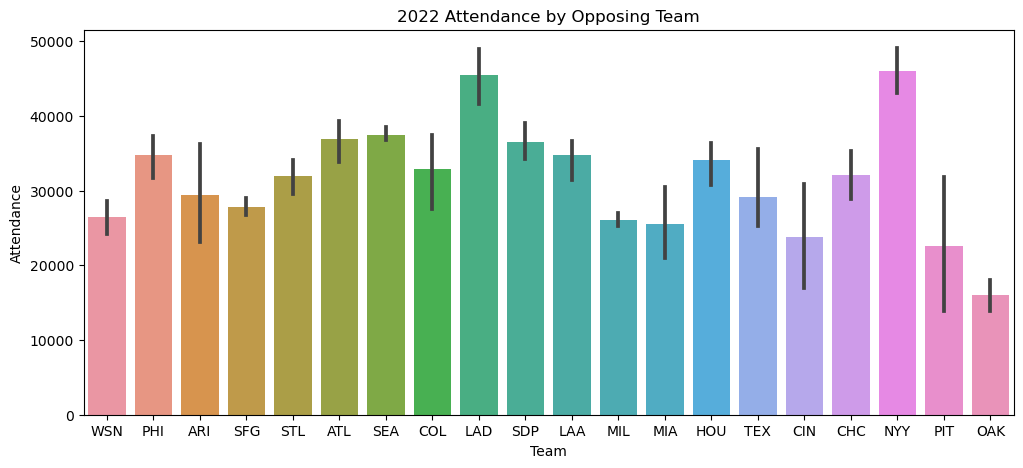

```python
#2022 Attendance by Opposing Team Barplot
fig = plt.subplots(figsize=(12, 5)) #set figure size

bar = sns.barplot(data = df_22, x = df_22.Opp, y = df_22.Attendance)

plt.title('2022 Attendance by Opposing Team')
plt.xlabel('Team')
plt.ylabel('Attendance')

#displays error bars, representing the unaggregated spread of each team's attendance to a Mets' game
```

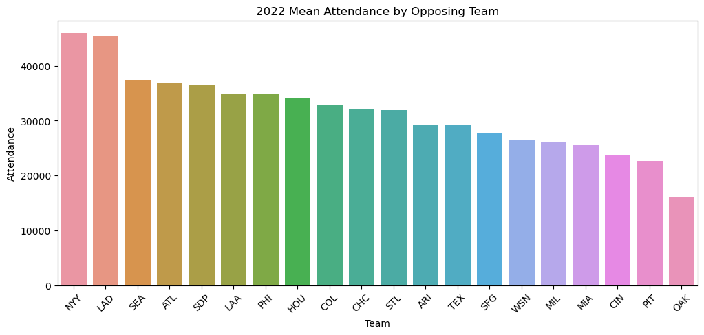

```python
#2022 Mean Attendance by Opposing Team Barplot

#sort df_22 grouped by aggregated mean of each opposing team, sorted in descending order
df_22_sorted = df_22.groupby('Opp')['Attendance'].mean().reset_index().sort_values(by='Attendance', ascending=False)

fig = plt.subplots(figsize=(12, 5)) #set figure size

bar = sns.barplot(data=df_22_sorted, x='Opp', y='Attendance')

plt.title('2022 Mean Attendance by Opposing Team')
plt.xlabel('Team')
plt.ylabel('Attendance')

plt.xticks(rotation=45)  #rotate x-axis labels
plt.show()
```

# 2022 Mean Attendance by Opposing Team

- The NYY, LAD, and SEA were the top three opposing teams that brought in the highest attendance to Mets' games in 2022. This implies that these three teams are the Mets' top rivals.

```python
#view top 10 attended games 2023
top10Attended23 = df_23.nlargest(10, "Attendance")
top10Attended23
#games 17, 54, and 18 were the respective top 3 attended games -
#where the NYM played against the LAD, COL, and LAD, respectively.
```

|  | Game | Date | Boxscore | Tm | Away | Opp | W/L | R | RA | Inn | ... | GB | Win | Loss | Save | Time | D/N | Attendance | cLI | Streak | Orig. Scheduled |
| --- | --- | --- | --- | --- | --- | --- | --- | --- | --- | --- | --- | --- | --- | --- | --- | --- | --- | --- | --- | --- | --- |
| 16 | 17 | Monday Apr 17 | boxscore | NYM | @ | LAD | W | 8 | 6 | NaN | ... | 2.0 | Peterson | Vesia | Ottavino | 2:50 | N | 50313.0 | 1.17 | +++++ | NaN |
| 53 | 54 | Sunday May 28 | boxscore | NYM | @ | COL | L | 10 | 11 | NaN | ... | 5.5 | Lambert | Nogosek | NaN | 2:57 | D | 47471.0 | 1.19 | -- | NaN |
| 17 | 18 | Tuesday Apr 18 | boxscore | NYM | @ | LAD | L | 0 | 5 | NaN | ... | 3.0 | Kershaw | Megill | NaN | 2:33 | N | 46884.0 | 1.18 | - | NaN |
| 100 | 101 | Wednesday Jul 26 | boxscore | NYM | @ | NYY | L | 1 | 3 | NaN | ... | 17.5 | Rodón | Quintana | Holmes | 2:32 | N | 46761.0 | 0.35 | - | NaN |
| 99 | 100 | Tuesday Jul 25 | boxscore | NYM | @ | NYY | W | 9 | 3 | NaN | ... | 17.5 | Verlander | Germán | NaN | 3:11 | N | 46540.0 | 0.30 | + | NaN |
| 109 | 110 | Saturday Aug 5 | boxscore | NYM | @ | BAL | L | 3 | 7 | NaN | ... | 21.0 | Gibson | Megill | NaN | 2:51 | N | 44326.0 | 0.19 | ----- | NaN |
| 67 | 68 | Wednesday Jun 14 | boxscore | NYM | NaN | NYY | W-wo | 4 | 3 | 10.0 | ... | 10.0 | Leone | Abreu | NaN | 3:17 | N | 44121.0 | 0.69 | + | NaN |
| 18 | 19 | Wednesday Apr 19 | boxscore | NYM | @ | LAD | W | 5 | 3 | NaN | ... | 2.0 | Yacabonis | Syndergaard | Ottavino | 2:51 | D | 43990.0 | 1.10 | + | NaN |
| 66 | 67 | Tuesday Jun 13 | boxscore | NYM | NaN | NYY | L | 6 | 7 | NaN | ... | 9.5 | Marinaccio | Walker | King | 3:19 | N | 43707.0 | 0.74 | -- | NaN |
| 7 | 8 | Friday Apr 7 | boxscore | NYM | NaN | MIA | W | 9 | 3 | NaN | ... | 2.0 | Megill | Cabrera | NaN | 3:01 | D | 43590.0 | 1.01 | + | NaN |

10 rows × 22 columns

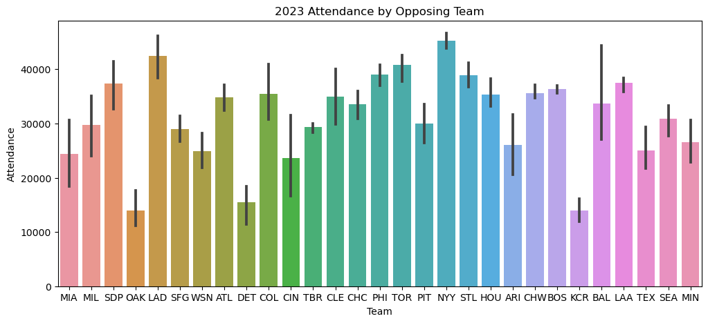

```python
#Repeat Barplot for 2023
#2023 Attendance by Opposing Team Barplot
fig = plt.subplots(figsize=(12, 5)) #set figure size

bar = sns.barplot(data = df_23, x = df_23.Opp, y = df_23.Attendance)

plt.title('2023 Attendance by Opposing Team')
plt.xlabel('Team')
plt.ylabel('Attendance')

#displays error bars, representing the unaggregated spread of each team's attendance to a Mets' game
```

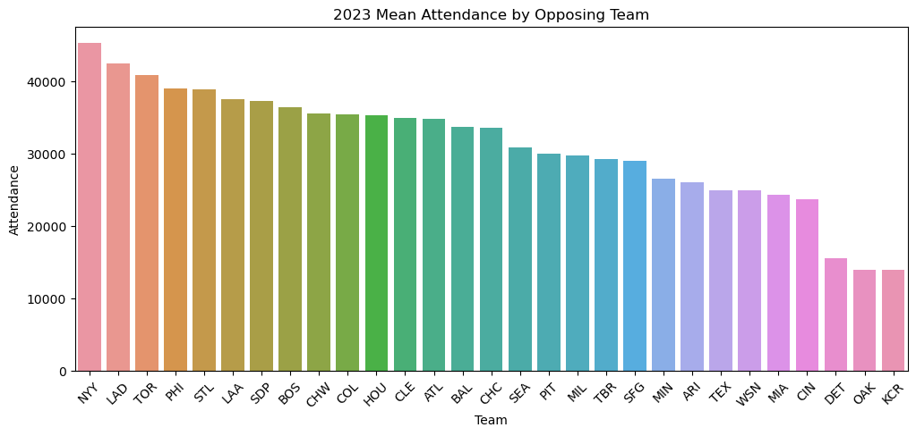

```python
#Repeat Aggregated Barplot for 2023
#2023 Mean Attendance by Opposing Team Barplot

#sort df_22 grouped by aggregated mean of each opposing team, sorted in descending order
df_23_sorted = df_23.groupby('Opp')['Attendance'].mean().reset_index().sort_values(by='Attendance', ascending=False)

fig = plt.subplots(figsize=(12, 5)) #set figure size

bar = sns.barplot(data=df_23_sorted, x='Opp', y='Attendance')

plt.title('2023 Mean Attendance by Opposing Team')
plt.xlabel('Team')
plt.ylabel('Attendance')

plt.xticks(rotation=45)  #rotate x-axis labels
plt.show()
```

# 2023 Mean Attendance by Opposing Team

- The NYY, LAD, and TOR were the top three opposing teams that brought in the highest attendance to Mets' games in 2023. This implies that these three teams are the Mets' top rivals this season. Between 2022 and 2023 we can infer that the Mets' biggest rivals are the NYY and the LAD because games against these teams brought in the highest attendence both years. Especially, the NYY having the top attended games implies a fierce rivalry as both teams are New York teams.

# Bottom 5 Attended Games Analysis

```python
#view bottom 5 attended games 2022
bottom5Attended22 = df_22.nsmallest(5, "Attendance")
bottom5Attended22
```

|  | Game | Date | Boxscore | Tm | Away | Opp | W/L | R | RA | Inn | ... | GB | Win | Loss | Save | Time | D/N | Attendance | cLI | Streak | Orig. Scheduled |
| --- | --- | --- | --- | --- | --- | --- | --- | --- | --- | --- | --- | --- | --- | --- | --- | --- | --- | --- | --- | --- | --- |
| 136 | 137 | Wednesday Sep 7 (1) | boxscore | NYM | @ | PIT | W | 5 | 1 | NaN | ... | up 0.5 | Bassitt | Underwood | NaN | 2:36 | D | 8717.0 | 1.09 | + | NaN |
| 135 | 136 | Tuesday Sep 6 | boxscore | NYM | @ | PIT | L | 2 | 8 | NaN | ... | Tied | Keller | Walker | NaN | 3:10 | N | 8817.0 | 0.99 | --- | NaN |
| 137 | 138 | Wednesday Sep 7 (2) | boxscore | NYM | @ | PIT | W | 10 | 0 | NaN | ... | up 0.5 | deGrom | Oviedo | NaN | 3:17 | N | 9824.0 | 1.13 | ++ | NaN |
| 71 | 72 | Friday Jun 24 | boxscore | NYM | @ | MIA | W | 5 | 3 | NaN | ... | up 5.0 | Walker | Alcántara | Díaz | 3:03 | N | 11444.0 | 1.11 | + | NaN |
| 138 | 139 | Friday Sep 9 | boxscore | NYM | @ | MIA | L | 3 | 6 | NaN | ... | 0.5 | Cabrera | Peterson | Floro | 3:05 | N | 12692.0 | 1.11 | - | NaN |

5 rows × 22 columns

```python
#create df of bottom 5 attended games' Game Number and CLI
cLI_df_22 = bottom5Attended22[['Game','cLI']]
print(cLI_df_22)
```

```
     Game   cLI
136   137  1.09
135   136  0.99
137   138  1.13
71     72  1.11
138   139  1.11
```

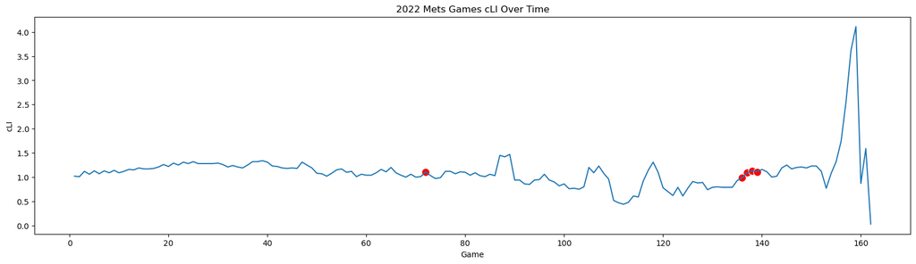

```python
#2022 times series of Met Games cLI

# cLI = Championship Leverage Index
# The importance of this game on the team's probability of winning the World Series.
# 1.0 is average importance, below 1.0 is below average importance and above 1.0 is above average importance.
# https://www.baseball-reference.com/teams/NYM/2022-schedule-scores.shtml

fig = plt.subplots(figsize=(20, 5)) #set figure size

plot = sns.lineplot(data = df_22, x = df_22.Game , y = df_22.cLI)
sns.scatterplot(data = cLI_df_22, x = 'Game', y = 'cLI', color = 'red', marker = 'o', s = 100, ax = plot) #plots bottom 5 games cLI

plt.title('2022 Mets Games cLI Over Time')
plt.xlabel('Game')
plt.ylabel('cLI')
```

# 2022 Mets Games cLI Over Time (Game Number)

- Around mid-season there was 1 game with the lowest attendance and there were 4 games near the end of the season that made up the bottom 5 attended games. The cLI over the 2022 season was relatively stagnant hovering around 1.0, signifying average cLI, until the end of the season where cLI dramatically increased then decreased. This indicates that the Mets' games near the end of the season were very important for their odds to win the World Series.
- It is important to note that all bottom 5 games were away games played against PIT and MIA. Low attendance for away games is more expected than those played at home where there are more local fans.

```python
#view bottom 5 attended games 2023
bottom5Attended23 = df_23.nsmallest(5, "Attendance")
bottom5Attended23
```

|  | Game | Date | Boxscore | Tm | Away | Opp | W/L | R | RA | Inn | ... | GB | Win | Loss | Save | Time | D/N | Attendance | cLI | Streak | Orig. Scheduled |
| --- | --- | --- | --- | --- | --- | --- | --- | --- | --- | --- | --- | --- | --- | --- | --- | --- | --- | --- | --- | --- | --- |
| 150 | 151 | Tuesday Sep 19 | boxscore | NYM | @ | MIA | L-wo | 3 | 4 | NaN | ... | 27.0 | Scott | Gott | NaN | 2:45 | N | 10897.0 | 0.00 | - | NaN |
| 13 | 14 | Friday Apr 14 | boxscore | NYM | @ | OAK | W | 17 | 6 | NaN | ... | 2.0 | Santana | Kaprielian | NaN | 3:29 | N | 11102.0 | 1.01 | ++ | NaN |
| 29 | 30 | Wednesday May 3 (1) | boxscore | NYM | @ | DET | L | 5 | 6 | NaN | ... | 5.0 | Alexander | Ottavino | Lange | 2:04 | D | 11363.0 | 1.04 | - | NaN |
| 107 | 108 | Thursday Aug 3 | boxscore | NYM | @ | KCR | L | 2 | 9 | NaN | ... | 20.0 | Singer | Carrasco | NaN | 2:14 | D | 11926.0 | 0.26 | --- | NaN |
| 151 | 152 | Wednesday Sep 20 | boxscore | NYM | @ | MIA | W | 8 | 3 | NaN | ... | 26.0 | Senga | Pérez | NaN | 3:04 | N | 12045.0 | 0.00 | + | NaN |

5 rows × 22 columns

```python
cLI_df_23 = bottom5Attended23[['Game','cLI']]
print(cLI_df_23)
```

```
     Game   cLI
150   151  0.00
13     14  1.01
29     30  1.04
107   108  0.26
151   152  0.00
```

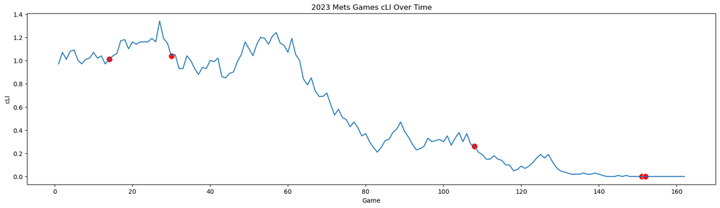

```python
#2023 times series of Met Games cLI
fig = plt.subplots(figsize=(20, 5)) #set figure size

plot = sns.lineplot(data = df_23, x = df_23.Game , y = df_23.cLI)
sns.scatterplot(data = cLI_df_23, x = 'Game', y = 'cLI', color = 'red', marker = 'o', s = 100, ax = plot) #plots bottom 5 games cLI

plt.title('2023 Mets Games cLI Over Time')
plt.xlabel('Game')
plt.ylabel('cLI')
```

# 2023 Mets Games cLI Over Time (Game Number)

- There were 2 games with the lowest attendance early in the season and there were 3 games near the mid-end of the season that made up the bottom 5 attended games. The cLI over the 2023 season seems to have a strong negative relationship with time hovering around and above 1.0, signifying average and above-average cLI, until about game 60. From game 60 onwards there is a strong negative decrease in cLI, indicating that the Mets' games from about mid-season until the end of the season had very poor and improbable odds to win (/make it to) the final matchups for the World Series.
- Similar to 2022, it is important to note that all bottom 5 games were away games. MIA games appeared again twice in the bottom 5 attended - where we can infer that NYM vs MIA games' attendees prefer to not attend these games. This also implies that there are perhaps not many Mets' fans in Miami, where these games are played. Again, low attendance for away games is more expected than those played at home where there are more local fans.
- Because of the negative slope in 2023, the following analyses will be a correlation matrix analysis of numeric variables.

```
                Game         R        RA  Attendance       cLI
Game        1.000000  0.002160 -0.009969    0.026899 -0.023905
R           0.002160  1.000000 -0.046303   -0.217154 -0.043531
RA         -0.009969 -0.046303  1.000000    0.013012  0.084043
Attendance  0.026899 -0.217154  0.013012    1.000000  0.056488
cLI        -0.023905 -0.043531  0.084043    0.056488  1.000000
```

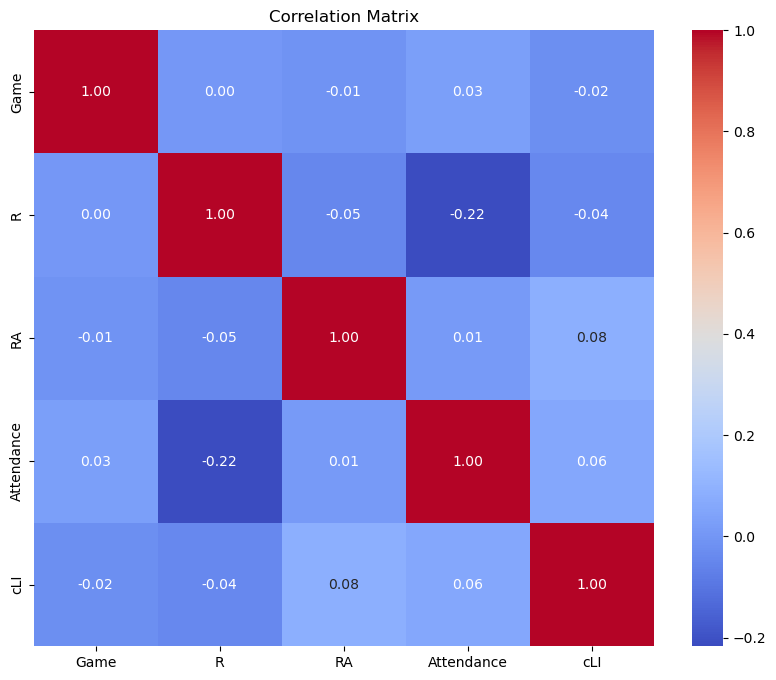

```python
#2022 Correlation Matrix of numeric varaibles
df_22_reduc = df_22[['Game', 'R', 'RA', 'Attendance', 'cLI']]
df_22_reduc
correlation_matrix = df_22_reduc.corr()

print(correlation_matrix)

plt.figure(figsize=(10, 8))
sns.heatmap(correlation_matrix, annot=True, cmap='coolwarm', fmt=".2f")
plt.title('Correlation Matrix')
plt.show()

#No correlation found between numeric variables 2022
```

```
                Game         R        RA  Attendance       cLI
Game        1.000000  0.012743 -0.048878    0.102219 -0.933546
R           0.012743  1.000000  0.080960    0.043141 -0.016510
RA         -0.048878  0.080960  1.000000    0.143785  0.075185
Attendance  0.102219  0.043141  0.143785    1.000000 -0.040704
cLI        -0.933546 -0.016510  0.075185   -0.040704  1.000000
```

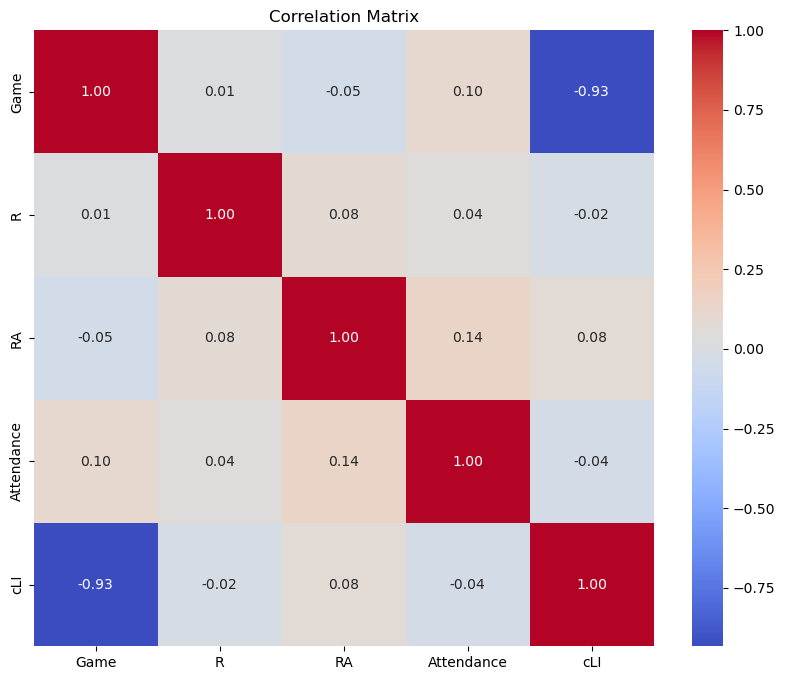

```python
#2023 Correlation Matrix of numeric varaibles
df_23_reduc = df_23[['Game', 'R', 'RA', 'Attendance', 'cLI']]
df_23_reduc
correlation_matrix = df_23_reduc.corr()

print(correlation_matrix)

plt.figure(figsize=(10, 8))
sns.heatmap(correlation_matrix, annot=True, cmap='coolwarm', fmt=".2f")
plt.title('Correlation Matrix')
plt.show()

#Strong negative correlation of -0.93 found between Game number and cLI.
#As the game number progresses, the cLI (probability of playing in the World Series) strongly decreases.
#Meaning that the 2023 season was not a good season for the Mets making it to the World Series playoffs.
```

# Notable trends or patterns in NYM performance

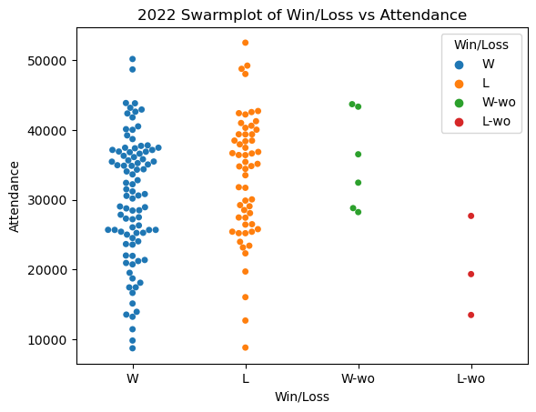

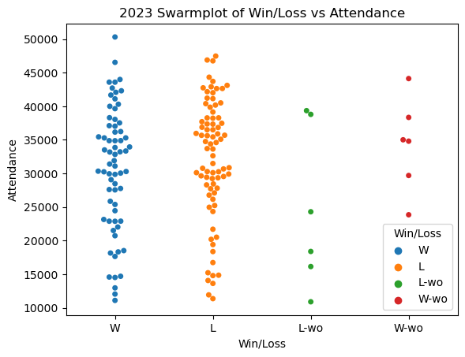

```python
#2022 Swarmplot of Win/Loss vs Attendance

sns.swarmplot(data = df_22, x = 'W/L', y = 'Attendance', hue = 'W/L')

plt.xlabel('Win/Loss')
plt.ylabel('Attendance')
plt.title('2022 Swarmplot of Win/Loss vs Attendance')

plt.legend(title = 'Win/Loss')
plt.show()


#2023 Swarmplot of Win/Loss vs Attendance

sns.swarmplot(data = df_23, x = 'W/L', y = 'Attendance', hue = 'W/L')

plt.xlabel('Win/Loss')
plt.ylabel('Attendance')
plt.title('2023 Swarmplot of Win/Loss vs Attendance')

plt.legend(title = 'Win/Loss')
plt.show()
```

# 2022 & 2023 Swarmplots of NYM's Win/Loss vs Attendance

```python
#reformat df_22 and df_23 so that 'Away' column NaN are replaced with 'Home' and '@' are replaced with 'Away'
#to better indicate home or away game

df_22['Away'] = df_22['Away'].fillna('').replace('','Home')
df_22['Away'] = df_22['Away'].replace('@', 'Away')
print(df_22['Away'])

df_23['Away'] = df_23['Away'].fillna('').replace('','Home')
df_23['Away'] = df_23['Away'].replace('@', 'Away')
print(df_23['Away'])
```

```
0      Away
1      Away
2      Away
3      Away
4      Away
       ...
157    Away
158    Away
159    Home
160    Home
161    Home
Name: Away, Length: 162, dtype: object
0      Away
1      Away
2      Away
3      Away
4      Away
       ...
157    Home
158    Home
159    Home
160    Home
161    Home
Name: Away, Length: 162, dtype: object
```

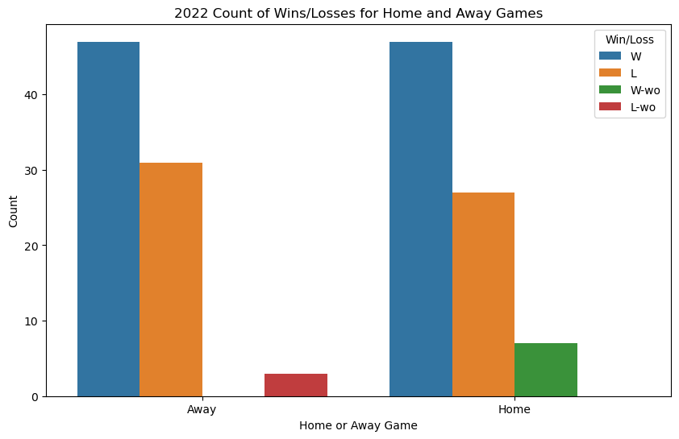

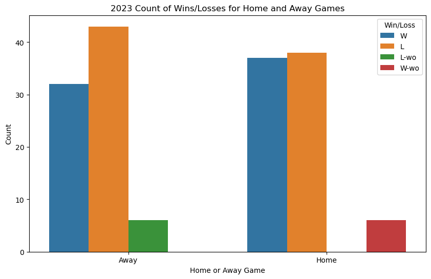

```python
#2022 Countplot of Wins/Losses for Home and Away Games

plt.figure(figsize=(10, 6))
sns.countplot(data = df_22, x = 'Away', hue = 'W/L')

plt.xlabel('Home or Away Game')
plt.ylabel('Count')
plt.title('2022 Count of Wins/Losses for Home and Away Games')

plt.legend(title = 'Win/Loss')
plt.show()



#2023 Countplot of Wins/Losses for Home and Away Games

plt.figure(figsize=(10, 6))
sns.countplot(data = df_23, x = 'Away', hue = 'W/L')

plt.xlabel('Home or Away Game')
plt.ylabel('Count')
plt.title('2023 Count of Wins/Losses for Home and Away Games')

plt.legend(title = 'Win/Loss')
plt.show()
```

```python
#reformat df_22 and df_23 so that 'W/l' column W-wo are replaced with 'W' and 'L-wo' are replaced with 'L'
#to better visualize total wins and losses

df_22['W/L'] = df_22['W/L'].replace('W-wo','W')
df_22['W/L'] = df_22['W/L'].replace('L-wo','L')
print(df_22['W/L'])

df_23['W/L'] = df_23['W/L'].replace('W-wo','W')
df_23['W/L'] = df_23['W/L'].replace('L-wo','L')
print(df_23['W/L'])
```

```
0      W
1      W
2      W
3      L
4      L
      ..
157    L
158    L
159    W
160    W
161    W
Name: W/L, Length: 162, dtype: object
0      W
1      L
2      W
3      W
4      L
      ..
157    L
158    W
159    W
160    W
161    L
Name: W/L, Length: 162, dtype: object
```

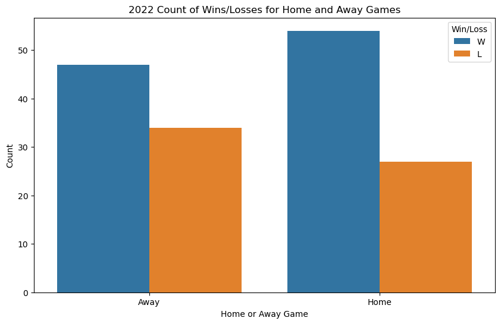

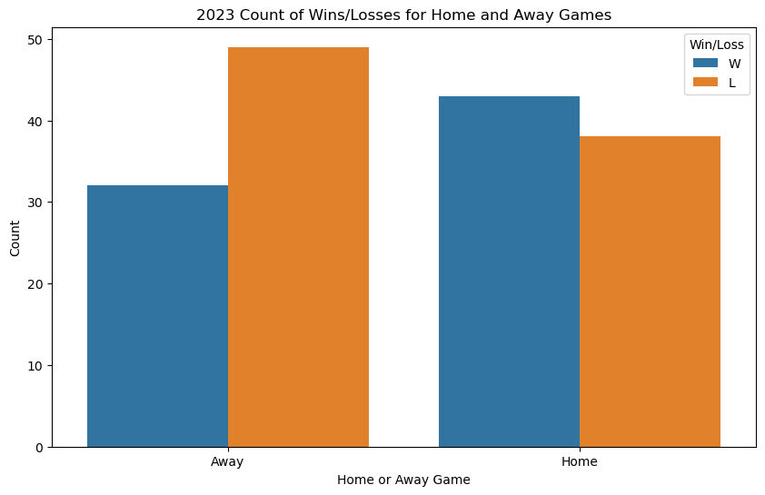

```python
#2022 Countplot of Wins/Losses for Home and Away Games

plt.figure(figsize=(10, 6))
sns.countplot(data = df_22, x = 'Away', hue = 'W/L')

plt.xlabel('Home or Away Game')
plt.ylabel('Count')
plt.title('2022 Count of Wins/Losses for Home and Away Games')

plt.legend(title = 'Win/Loss')
plt.show()



#2023 Countplot of Wins/Losses for Home and Away Games

plt.figure(figsize=(10, 6))
sns.countplot(data = df_23, x = 'Away', hue = 'W/L')

plt.xlabel('Home or Away Game')
plt.ylabel('Count')
plt.title('2023 Count of Wins/Losses for Home and Away Games')

plt.legend(title = 'Win/Loss')
plt.show()
```

# 2022 & 2023 Count of NYM's Wins/Losses for Home and Away Games

- As predicted, across both years there are more wins than losses at home games, where the NYM are more comfortable playing (and have more fans supporting them in the stands).
- Though in 2022, the opposite is not true for away games, where more games were actually won than lost - thus indicating an overall better performing season. While in 2023, significantly more games were lost than won at away games.
- Additionally, for 2023, there is not a major increase between games won and lost at home - when games won at home in 2022 were roughly double the games lost at home.

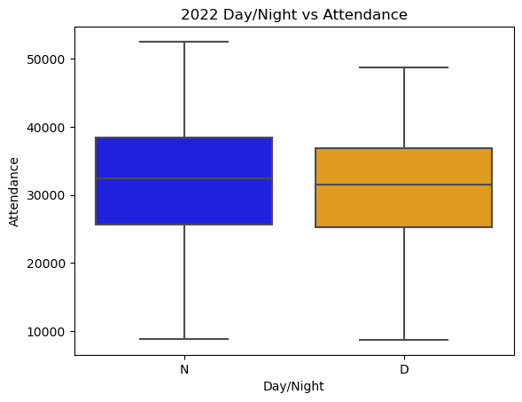

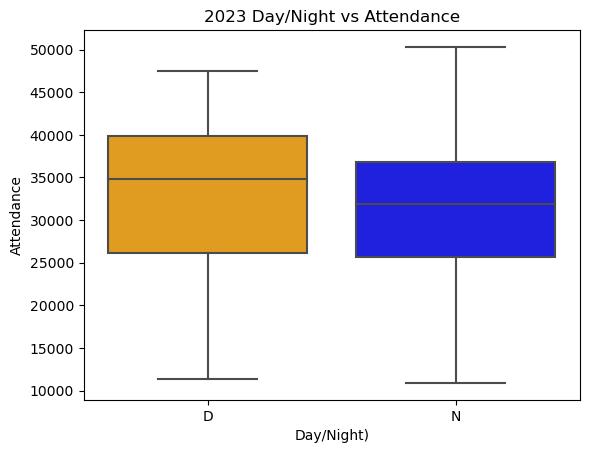

```python
#2022 D/N (Day/Night Games) vs Attendance

colors = {'D': 'orange', 'N': 'blue'}
sns.boxplot(data = df_22, x = 'D/N', y = 'Attendance', palette = colors)

plt.xlabel('Day/Night')
plt.ylabel('Attendance')
plt.title('2022 Day/Night vs Attendance')
plt.show()


#2023  D/N (Day/Night Games) vs Attendance

colors = {'D': 'orange', 'N': 'blue'}
sns.boxplot(data = df_23, x = 'D/N', y = 'Attendance', palette = colors)

plt.xlabel('Day/Night)')
plt.ylabel('Attendance')
plt.title('2023 Day/Night vs Attendance')
plt.show()
```

# 2022 & 2023 D/N (Day/Night Games) vs Attendance

- I predicted that higher attendance would be somewhat dependent on if the game occurs at night / later in the day because many games are played on weekdays and many attendees have work or are busy during the day. It is interesting that higher attendance flips between night and day between 2022 and 2023, with higher attendance during the day for 2023. Though the outliers at night 2023 do surpass the outliers during the day.